# Our Mindfulness Community

Carey Huh, Ph.D.

2022-12-13

## Project Background

- Susan Samueli Integrative Health Institute has graciously offered the UCI and the community opportunities to practice mindful meditatations for two years now
- My name is Carey Huh and I worked at UCI as a neuroscientist for over 5 years
- My mindfulness journey began with a free MBSR course offered by SSIHI in May 2020, at the start of the COVID-19 pandemic
- Since then, I have been a regular practitioner at SSIHI’s weekday community meditations and yoga for wellbeing classes
- In April 2021, I participated in the 8-week Mindful Self-Compassion course offered by SSIHI, taught by Amy Noelle
- The consistent mindfulness practices and self-compassion teachings helped to completely transform my outlook on life!
- I changed my career to a data scientist working for the CDC Foundation
- A career that allows me to work from home means that I can stay connected to the UCI mindfulness community that I have grown to love and cherish

## Project Motivation

- As a passion project, I have been monitoring attendance at SSIHI mindfulness community classes since April of 2021
- This attendance data only contain aggregated summary statistics and the anonymity of participants is strictly protected
- Using the data I have collected, I wanted to take the opportunity to show how the community has stayed consistent in number throughout the length of the program
- In particular, individual engagement during community meditation classes has steadily increased, indicating that individual participation and willingness to share in the sense of community has only grown stronger, not weaker, over time

## Weekday Community Meditation

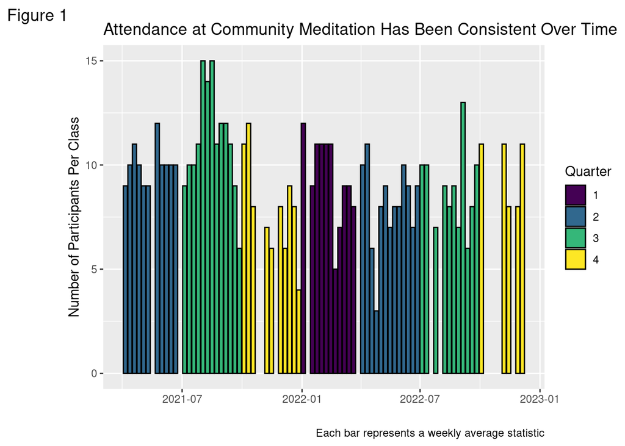